# 4M074 Probabilités Numériques et Statistique Computationnelle

## 3.2 un exemple de `findInterval`

rappel de la définition de l’inverse généralisée d’une fonction réelle $F$, noté $F^{-1}$

$$F^{-1}(x) = \inf\{y\in \mathbb{R}: F(y)\geq x\}$$

```r
x_inv<-findInterval(0.6, cumsum(dbinom(0:10,10,0.2)))
```

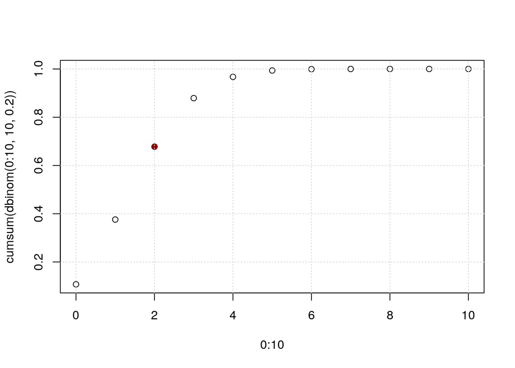

Figure 7: ex. de la fonction *findInterval*

```r
plot(0:10,cumsum(dbinom(0:10,10,0.2)))
points(x_inv,cumsum(dbinom(0:10,10,0.2))[x_inv+1] , col='darkred',pch=19)
grid()
```

## 3.3 Copule Gaussienne

On commence par un cas particulier ($dim = 2$). La copule est un objet pour décrire la dépendance entre les v.a. Pour les v.a. gaussiennes, la dépendance est totalement définie par la matrice de covariance.

Soit $(X_1,X_2) \sim \mathcal{N}_2 (0, \Gamma_2)$, où la matrice de covariance est

$$\Gamma_2 = \begin{pmatrix}
1 & \rho \\
\rho & 1
\end{pmatrix}$$

Par construction, on a bien

$$\mathcal{L}(X_1) =
\mathcal{L}(X_2) = \mathcal{N}(0,1).$$

Alors, comme la f.d.r. $\Phi\in \mathscr{C}^0$

$$(U_1,U_2) = (\Phi(X_1),\Phi(X_2))$$

est la copule qu'on cherche à simuler.

On revient au cas où $dim = n$. Si on simule $(Z_1,\dots,Z_n)$ par

$$\forall i \in \{1,2,\dots,n\}\qquad Z_i = \sqrt{\rho} G_0 + \sqrt{1-\rho} G_i$$

où $G_i$ sont les normales standards indépendantes, il est facile de vérifier que

$$\mathrm{Var}[Z_i] = 1\qquad et \qquad
\mathrm{Cov}[Z_i Z_j] = \rho \qquad \forall i\neq j\in\{1,2,\dots,n\}$$

Alors, la matrice de covariance associée est de la forme

$$\Gamma_n = \begin{pmatrix}
1 & \rho & \cdots & \rho \\
\rho & 1 & \cdots & \rho \\
\vdots & \vdots & \ddots & \vdots \\
\rho & \rho & \cdots & 1
\end{pmatrix}$$

Donc, pour simuler $(U_1,U_2,\dots,U_n)$ la copule gaussienne associée, il faut juste prendre

$$U_i = \Phi(Z_i) \qquad \forall i \in \{1,2,\dots,n\}$$

L’intérêt de cette méthode est que si vous voulez simuler les vecteurs gaussiens avec $\Gamma$ différents, on peut simuler $(G_i)_{1\leq i \leq N}$ une seule fois. Ceci nous permet aussi de faire la simulation ‘dépendante’ parallèlement.

## 3.4 Urne d'Ehrenfest

On remarque que la loi invariante est bien $\mathcal{B}(d,\frac12)$.

$$\forall k \in [0:d], \qquad \mathbf{P}(X_n = k) =
\frac{1}{2^d}\binom{d}{k}$$

### 3.4.1 Pourquoi ?

Une manière intuitive de regarder ce problème est de suivre une boule précise. Imaginons que l’on a déjà fait une infinité de transitions. Alors, le fait que cette boule soit dans A ou dans B est indépendant que d’autres boules, et suit une loi de Bernoulli de paramètre $\frac12$. Donc, le cardinal de l’urne A suit une loi binomiale.

Or, il est facile de vérifier que cette chaîne est irréductible et récurrente positive (ensemble d’états finie). Elle admet donc une unique loi invariante. Alors il suffit de vérifier que

$$X_0 \sim \mathcal{B}(d,\frac12)\implies X_1 \sim \mathcal{B}(d,\frac12)$$

### 3.4.2 Chaîne d'Ehrenfest modifiée

On modifie un peu la modélisation précédente en considérant la règle suivante: “*on tire un numéro de balle selon la loi uniforme sur $\{1,2,\dots,d\}$ et à un tirage $i$ on déplace la balle numéro $i$ d’une urne à l’autre **avec probabilité 1/2***”.

La chaîne modifiée est apériodique et irréductible d’états finis, il y a donc une convergence à vitesse géométrique vers la loi invariante $\pi$. On note $\mu_0$ la loi initiale et $M'$ la transition modifiée

$$\forall f \in \mathcal{B}_b([0:d]),\qquad |\mu_0 (M')^n (f) - \pi (f)|\leq
C\alpha^n \Vert f\Vert_{\infty}$$

avec $C>0$ une const. et $0<\alpha<1$.

On remarque que la chaîne originale est périodique avec période = 2, il n’y a donc pas de convergence vers la loi invariante.

On note $M$ le noyau de transition pour la chaîne originale et $\pi$ la loi invariante associée (binomiale). On a

$$M'(x, dy) = \frac12 M(x,dy) + \frac12\delta_x(dy)$$

Alors, il est facile de vérifier que

$$\pi M' = \frac12\pi M + \frac12\pi = \pi$$

Par l’unicité de la loi invariante, on a $\pi = \pi_0$.

## 3.5 Processus de Poisson inhomogène

Soit $\lambda:[0,+\infty[ \to ]0, +\infty[$ une fonction strictement positive, appelée fonction d’intensité. On considère maintenant des instants de sauts $(T_n)_{n \geq 1}$ (avec toujours $T_0 = 0$) donnés par la dynamique $T_{n} = T_{n-1} + S_n$ où pour tout $n \geq 1$, $S_n$ est une variable aléatoire sur $]0,+\infty[$ définie conditionnellement à $T_{n-1}$ par

$$\begin{aligned}
\forall s > 0, \forall t_{n-1} > 0, \quad
\mathbf{P} \bigl[S_n > s \; \bigl\vert \; T_{n-1} = t_{n-1} \bigr] &= \exp \bigl(-\int_0^s \lambda(u + t_{n-1}) d u \bigr) \\
&= \exp \bigl(- (\Lambda(t_{n-1} + s) - \Lambda(t_{n-1})) \bigr) \\
\end{aligned}$$

avec $\Lambda(t) = \int_0^t \lambda(u) d u$ l’intensité intégrée. Dans la suite on note $\Lambda^{-1}$ la réciproque de $\Lambda$.

### 3.5.1 Simulation par inverse de l'intensité intégrée

Montrer que si $E \sim \mathcal{E}(1)$ et que $t_{n-1}$ est fixé, alors la variable aléatoire $X = \Lambda^{-1}\bigl(E + \Lambda(t_{n-1})\bigr) - t_{n-1}$ vérifie

$$\forall s > 0, \quad
\mathbf{P} \bigl[X > s \bigr] = \exp \bigl(- (\Lambda(t_{n-1} + s) - \Lambda(t_{n-1})) \bigr),$$

*Preuve* :

Puisque $\lambda$ est une fonction strictement positive, l’application $\Lambda : t \rightarrow \Lambda(t)$ est continue et strictement croissante sur $\mathbb{R}_+$ (donc bijective).

Alors, on a

$$\begin{aligned}
\mathbf{P}\big[ X > s\big] &= \mathbf{P}\big[\Lambda^{-1}\big(E + \Lambda(t_{n-1})\big) - t_{n-1} > s \big]\\
&=\mathbf{P}\big[E + \Lambda(t_{n-1}) > \Lambda(t_{n-1}+s)\big]\\
&=\mathbf{P}\big[E > \Lambda(t_{n-1}+s)-\Lambda(t_{n-1}) \big]\\
&=\exp \bigl(- (\Lambda(t_{n-1} + s) - \Lambda(t_{n-1})) \bigr)
\end{aligned}$$

C’est-à-dire,

$$\mathcal{L}\big(X \; \big\vert \; T_{n-1} = t_{n-1}\big) = \mathcal{L}\big(S_n \; \big\vert \; T_{n-1} = t_{n-1}\big)$$

□  
En déduire une méthode de simulation des instants de sauts $(T_n)_{n \geq 1}$ et du processus de comptage associé (appelé processus de Poisson inhomogène de fonction d’intensité $\lambda$).

Tester cette méthode avec la fonction d’intensité $\lambda(t) = 0.1 + 5t$.

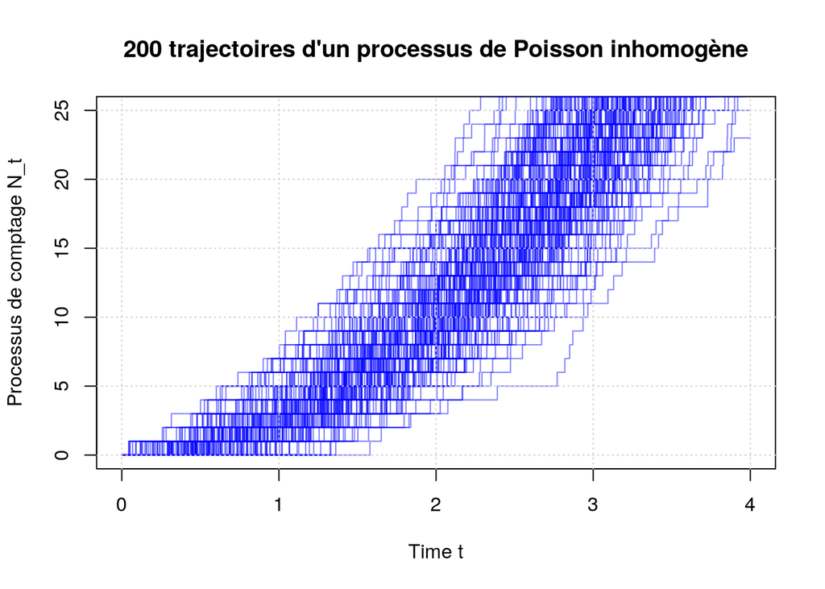

Figure 8: Processus de Poisson inhomogène

```r
lambda <- function(t) return(0.1 + 5*t)
Lambda <- function(t) return(0.1*t + 2.5*t^2 )
Lambda_inv <- function(s) return(-0.02 + 0.2*sqrt(0.01+10*s))

X_cond <- function(t) {
    E <- rexp(1);
    X <- Lambda_inv (E + Lambda(t)) - t;
    return(X);
}


# svglite("poisson_inhomogene.svg")
Npaths <- 200
T <- 4
plot(NULL, xlim=c(0,T), ylim=c(0,25), xlab="Time t", ylab="Processus de comptage N_t",
     main = paste(Npaths, "trajectoires d'un processus de Poisson inhomogène"))

# on fait simple et on illustre ici l'utilisation d'une boucle for et d'une boucle while
for (k in 1:Npaths) {
    T_n <- 0
    path <- 0
    while (T_n < T) {
        T_n <- T_n + X_cond(T_n)
        if (T_n < T) path <- c(path, T_n)
    }
    N_T <- length(path)-1
    N <- 0:N_T

    # on ajoute pour faire joli le dernier point (T, N_T)
    path <- c(path, T)
    N <- c(N, N_T)

    lines(path, N, type="s", col=rgb(0,0,1,alpha=0.5))
}
grid()
```

### 3.5.2 Simulation par la méthode des sauts fictifs (thinning)

On suppose maintenant que la fonction d’intensité est bornée

$$\exists \bar \lambda > 0, \quad \forall t \ge 0, \quad \lambda(t) \le \bar \lambda.$$

Soit $(\bar T_n)_{n \geq 1}$ les instants de sauts d’un processus de poisson $(\bar N_t) {t \geq 0}$ d’intensité $\bar \lambda$. On peut simuler les instants de sauts $(T_n) (n \ge 1)$ en supprimant certains sauts de $(\bar T_n) {n \ge 1}$. Plus précisément, on considère $(U_n)_{n \ge 1}$ une suite *i.i.d.* de loi uniforme sur $[0,1]$ et on construit la suite d’indices $(\tau_n)_{n \ge 1}$ par la récurrence

$$\forall n \ge 0, \quad \tau_{n+1} =
\min \Bigl\{ k > \tau_n, U_k \le \frac{\lambda(\bar T_k)}{\bar \lambda} \Bigr\}
\qquad \tau_0 = 0$$

Alors les sauts de $(\bar N_t)_{t \ge 0}$ d’indices $(\tau_n)_{n \ge 1}$ sont les sauts d’un processus de Poisson inhomogène de fonction d’intensité $\lambda$. On peut alors construire $(T_n)_{n \ge 1}$ en posant $T_n = \bar T_{\tau_n}$.

```r
tau_update <- function(tau,lambda_bar, T_bar){

    # tau: tau_n
    # lambda_bar: la borne de l'indensité
    # T_bar: un vecteur des instants de sauts d'un processus de Poisson

    k <- tau
    while(runif(1) > T_bar[k]/lambda_bar){
        k <- k+1
    }
    # la sortie: tau_{n+1}
    return(k)
}
```

## 3.6 Variable de contrôle

Soit $X$ une v.a. et on veut estimer sa moyenne $\mathbf{E}[X]$ par la méthode de Monte-Carlo. Soit $Y$ une v.a. telle que l’on connaît la moyenne $\mathbf{E}[Y]$. Alors, on a pour, tout $\alpha$,

$$\mathbf{E}[X] = \mathbf{E}[X-\alpha Y] + \alpha \mathbf{E}[Y]$$

On suppose que l’on sait simuler suivant la loi $\mathcal{L}(X)$. Alors, on s’intéresse au cas où

$$\mathrm{Var}[X - \alpha Y] \leq \mathrm{Var}[X]$$

Il est facile de vérifier qu’une condition nécessaire

$$\mathrm{Cov}[X,Y] \neq 0$$

## 3.7 Algorithme de Metropolis-Hastings

Ici, on donne une version un peu plus générale que dans la feuille de TP : On utilise l’opérateur intégrale au lieu de la matrice de transitions. Le but est de comprendre **pourquoi M-H nous donne un noyau de transition avec la bonne loi invariante** et **comment on fait la simulation**. On remarque que tous les calculs seront identiques si on utilise la représentation matricielle. On va d’abord voir la construction de noyau de transition et vérifier qu’il nous donne la bonne loi invariante par les calculs algébriques. Ensuite, on donne deux décompositions pour mieux comprendre la dynamique associée et l’idée de la construction. On remarque que ce genre de dynamique nous permet de construire d’autres algorithmes pour des scénarios différents.

On suppose qu’on a une mesure $\pi(dx)$ qui est absolument continue par rapport à la mesure (de Lebesgue) $dx$, et un noyau de transition $M(x,dy)$ tel que pour tous les $x$, $M(x,dy) = M(x,y)dy$ est une mesure de proba et est aussi absolument continue par rapport à $dy$.

Alors, on définit le noyau Métropolis-Hastings par

$$Q(x,dy) := r(x,y)M(x,dy) + \left(1 - \int r(x,s)M(x,ds) \right)\delta_x(dy)$$
avec
$$r(x,y) = \frac{\pi(y)M(y,x)}{\pi(x)M(x,y)}\wedge 1$$

Il est facile de vérifier que
$$\int \pi(dx)Q(x,dy)f(y) = \int f(y) \pi(dy)$$
pour n’importe quelle fonction de test mesurable bornée $f$.

### 3.7.1 Décomposition 1

Notons que $r(x,y)M(x,dy)$ n’est pas un noyau Markovien ($\forall x, \int M(x,dy) = 1$). Mais, on en déduit que

$$Q(x,dy) := \int r(x,s)M(x,ds) \cdot \frac{r(x,y)M(x,dy)}{\int r(x,s)M(x,ds)} + \left(1 - \int r(x,s)M(x,ds) \right)\delta_x(dy)$$
où
$$\frac{r(x,y)M(x,dy)}{\int r(x,s)M(x,ds)}$$
est bien un noyau markovien. Alors, pour chaque état $x$, on peut voir la loi de $y$ comme une loi de mélange de $\frac{r(x,y)M(x,dy)}{\int r(x,y)M(x,dy)}$ et $\delta_x (dy)$, avec proba
$$\left( \int r(x,s)M(x,ds) , 1- \int r(x,s)M(x,ds)\right)$$

### 3.7.2 Décomposition 2 (pour simulation)

En même temps, on a une autre décomposition pour simplifier la procédure de simulation. On considère deux étapes :

- simuler $\widetilde{Y} \sim M(x, ds)$
- simuler $u \sim \mathscr{U}(0,1)$
  - si $u < r(x, \widetilde{Y})$, on pose $Y = \widetilde{Y}$
  - sinon, on pose $Y = x$

Ceci équivaut à dire que l’on prend

$$\tilde{Q}(x,dy) := \int_s M(x, ds)\left\{
r(x,s)\delta_s(dy) + (1-r(x,s))\delta_x(dy)
\right\}$$
Il est aussi très facil à vérifier que
$$Q(x,dy) = \tilde{Q}(x,dy)$$